# OKCupid_data

Roko Mijic

18 May 2016

```r
df = dplyr::filter(df, d_gender == "Man" )

df = reduce_data(df, frac = 0.80)

Total_vals = dim(df)[1]*dim(df)[2]
Total_vals
```

```
## [1] 84419328
```

```r
frac_na = sum(is.na(df))/Total_vals
frac_na
```

```
## [1] 0.7415949
```

Do some minor renaming of the question data:

```r
colnames(qdata)[[1]] = "q_num"
rownames(qdata) = paste("q", rownames(qdata), sep = "" )
```

Now we will process the question data to find question numbers with two answers, three answers and four answers

```r
q_ans_2 = dplyr::filter(qdata, is.na(option_3), is.na(option_4))$q_num
q_ans_3 = dplyr::filter(qdata, !is.na(option_3), is.na(option_4))$q_num
q_ans_4 = dplyr::filter(qdata, !is.na(option_3), !is.na(option_4))$q_num
```

We write a function which automatically turns a dataframe of binary factor features into numerical ones, another function to remove constant columns, and a final one to turn question numbers into descriptive question texts:

```r
# function to make a non-numeric dataframe into a numeric one
numericalize = function(x){  dm = data.matrix(x) ;  class(dm) = "numeric" ;  return(data.frame(dm-1)) }

# function to remove constant columns
deconstantize = function(x) {x[,apply(x, 2, var, na.rm=TRUE) != 0]}

# function to turn a set of question numbers into a set of descriptive question texts
descriptiveize = function(x) {return(qdata[match(x, qdata$q_num),2]) }
```

Now we get dataframes that are the data with just certain types of question included, for example two answer questions, three answer questions, etc:

```r
df_qs = dplyr::select( df, starts_with("q"))
df_ds = dplyr::select( df, starts_with("d"))
df_ps = dplyr::select( df, starts_with("p"))
df_2ansq = df_qs[, names(df_qs) %in% q_ans_2]
df_3ansq = df_qs[, names(df_qs) %in% q_ans_3]
df_4ansq = df_qs[, names(df_qs) %in% q_ans_4]
df_misc = dplyr::select( df, -starts_with("q"), -starts_with("p"), -starts_with("d") )
```

Turn the two-answer questions into 0-1 numericals:

```r
df_2ansq = numericalize(df_2ansq)
```

We can remove costant columns:

```r
df_2ansq = deconstantize(df_2ansq)
df_2ansq[1:5, 1:5]
```

```
##   q2 q12 q13 q14 q16
## 1 NA  NA  NA  NA  NA
## 2 NA   1   1   1   1
## 3 NA  NA   1   1  NA
## 4 NA  NA  NA  NA  NA
## 5 NA  NA  NA  NA  NA
```

compute the correlation matrix using “pairwise.complete.obs”, then find eigenvalues and eigenvectors

```r
corM = cor(df_2ansq, use = "pairwise.complete.obs"  )
corM[is.na(corM)] = 0
```

(*)

```r
eigenobj = eigen(corM, symmetric = TRUE)
rownames(eigenobj$vectors) = rownames(corM)
```

Examine the large eigenvalues, make a scree plot. Arbitrarily choose eigenvalue magnitude > 11.85 (this needs tinkering with using the scree plot)

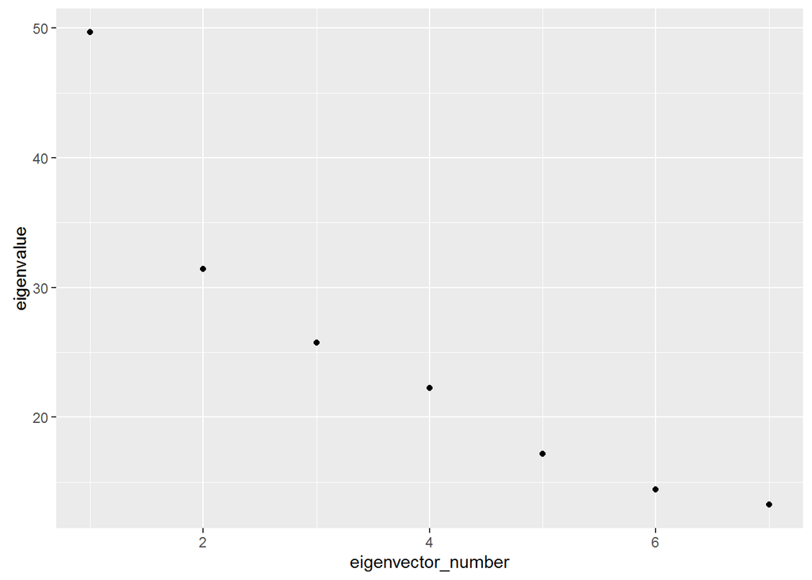

```r
large_evals_mask = abs(eigenobj$values) > 11.85

large_evals_abs = sort(abs((eigenobj$values)[large_evals_mask]), decreasing = TRUE)

large_evecs = (eigenobj$vectors)[,large_evals_mask]
eval_df = data.frame(eigenvector_number = c(1:length(large_evals_abs)), eigenvalue = large_evals_abs)

ggplot() + geom_point(data = eval_df  , aes(x = eigenvector_number, y=eigenvalue ) )
```

```r
corM[1:5,1:5]
```

```
##              q2         q12         q13         q14         q16
## q2   1.00000000  0.12206917 -0.02463079 -0.04235896  0.04231341
## q12  0.12206917  1.00000000 -0.15216061 -0.19317819 -0.09380399
## q13 -0.02463079 -0.15216061  1.00000000  0.76636895  0.10010008
## q14 -0.04235896 -0.19317819  0.76636895  1.00000000  0.11850642
## q16  0.04231341 -0.09380399  0.10010008  0.11850642  1.00000000
```

```r
print_evec = function(n){}

print(descriptiveize(names(sort(large_evecs[,1]))[1:10]))
```

```
## Source: local data frame [10 x 1]
##
##                                                                           text
##                                                                          (chr)
## 1                 Do you believe that Jesus died and was raised from the dead?
## 2            Would you date someone who is waiting until marriage to have sex?
## 3                                                           Are you Christian?
## 4                               Should burning your country's flag be illegal?
## 5                                                       Do you believe in God?
## 6                   Is there a such thing as having had too many sex partners?
## 7                  Is exposure to sexuality damaging to the minds of children?
## 8  Do you think angry or pornographic music lyrics should be kept, by law, awa
## 9                                         Do you think homosexuality is a sin?
## 10                 Is marriage a necessity for two people who love each other?
```

```r
print(descriptiveize(names(sort(large_evecs[,2])[1:10])))
```

```
## Source: local data frame [10 x 1]
##
##                                                                           text
##                                                                          (chr)
## 1                                                    Do you believe in ghosts?
## 2                                                  Do you believe in miracles?
## 3  Would you consider sleeping with someone who offered you a job promotion as
## 4                                                      Do you believe in fate?
## 5       Excluding childhood fights, have you ever punched someone in the face?
## 6  If a significant other told you that they had two-way communication with th
## 7       Would you like to 'live hard, die fast, and leave a beautiful corpse'?
## 8                                   Would you have sex with someone you hated?
## 9            Do you believe that dreams can be messages from a 'higher level'?
## 10        Have you ever traded a lover sexual favors for something you wanted?
```

```r
print(descriptiveize(names(sort(large_evecs[,3])[1:10])))
```

```
## Source: local data frame [10 x 1]
##
##                                                                           text
##                                                                          (chr)
## 1              Do you often have a hard time thinking of things to talk about?
## 2                              Could you date someone with no long-term goals?
## 3  Would you consider dating someone who, prior to meeting you, was regularly
## 4  Would you date someone who has never been in any kind of relationship befor
## 5                                        Did man make God or did God make man?
## 6  Someone offers to give you $100 if you *don't* vote in the next national el
## 7                   Would speaking in front of a large group make you nervous?
## 8  'It's not that I'm lazy, it's that I just don't care.'  Does this statement
## 9  Could you have a long-term relationship with someone who expressed that the
## 10                                    Are you quietly angry a lot of the time?
```

```r
print(descriptiveize(names(sort(large_evecs[,4])[1:10])))
```

```
## Source: local data frame [10 x 1]
##
##                                                                           text
##                                                                          (chr)
## 1    Would you need to sleep with someone before you considered marrying them?
## 2              Would you dump someone simply because they weren't good at sex?
## 3  Which is better: sex without sleeping together or sleeping together without
## 4             Would you rather date someone extremely hot or extremely honest?
## 5  If you had children, would it upset you to discover they were dumb, but nic
## 6        Would you find it easier to kill for your beliefs or to die for them?
## 7  Would you rather have extreme wealth for yourself or provide every homeless
## 8    Would you object to someone bringing a young child along on a first date?
## 9  If you were searching profiles for a match on OkCupid, which do you think w
## 10                                          Are you more horny or more lonely?
```

```r
print(descriptiveize(names(sort(large_evecs[,5])[1:10])))
```

```
## Source: local data frame [10 x 1]
##
##                                                                           text
##                                                                          (chr)
## 1                                                    Are you totally anti-war?
## 2  Do you believe that, when a soldier kills an enemy soldier in combat during
## 3                                       Should the death penalty be abolished?
## 4         Is it wrong to watch pornographic films if you're in a relationship?
## 5                                  Can you name 5 operas, and their composers?
## 6  Do you believe that it is your duty to educate people who don't share your
## 7          Is your duty to religion/God the most important thing in your life?
## 8  Do you feel that having sex with someone you have known less than one year
## 9                                         Do you keep a blog (online journal)?
## 10 Do you think that a person's musical preferences are a good indicator of in
```

```r
print(descriptiveize(names(sort(large_evecs[,6])[1:10])))
```

```
## Source: local data frame [10 x 1]
##
##                                                                           text
##                                                                          (chr)
## 1  Assuming you were in the position to do so and asked to make the final deci
## 2       Do you believe that adults should be able to carry firearms in public?
## 3                                  Could you imagine yourself killing someone?
## 4                  Are you smarter than the majority of people on this planet?
## 5  Have you made plans to survive a natural or man-made disaster where you liv
## 6                                 Are some human lives worth more than others?
## 7                Overall, what is a more valuable and worthy goal for society?
## 8                                            Are you smarter than most people?
## 9                          Would you date someone who kept a gun in the house?
## 10                         Has anyone ever told you that you are intimidating?
```

```r
print(descriptiveize(names(sort(large_evecs[,7])[1:10])))
```

```
## Source: local data frame [10 x 1]
##
##                                                                           text
##                                                                          (chr)
## 1  Would you ever consider an open marriage? That means you can sleep with oth
## 2  Would you consider dating someone who is already involved in an open or pol
## 3  Would you consider dating someone who works in a job that involves animal t
## 4                        Would you consider dating someone who wears dentures?
## 5  Could you date someone that has put off a relationship with someone else, w
## 6                             Would you ever take your family to a nude beach?
## 7  Would you consider dating someone who, prior to meeting you, was regularly
## 8                       Overall, has capitalism made the world a better place?
## 9  Would you consider having an open relationship (i.e., one where you can see
## 10       Could you date someone who has terrible taste when it comes to music?
```

We can also run factor analysis from the line (*) :

```r
fact_obj = fa(corM, nfactors = 17, rotate="oblimin")
fact_obj$values
```

```
##    [1] 49.024793180 30.737691020 24.992384459 21.582719717 16.409534036
##    [6] 13.699970982 12.546587418 10.580794801  8.524256827  7.863867910
##   [11]  6.963965666  6.841571735  6.124935266  5.936402358  5.382392271
##   [16]  5.103655908  4.619874341  4.339856714  4.295546865  4.070125342
##   [21]  3.790856960  3.754213133  3.596842528  3.505556423  3.445167093
##   [26]  3.299099382  3.226629634  2.961536417  2.838300220  2.742438388
##   [31]  2.684964023  2.594763525  2.539844928  2.451988565  2.439064230
##   [36]  2.426941041  2.372903511  2.341516911  2.262051093  2.212451079
##   [41]  2.169703745  2.138132550  2.130305120  2.070405441  2.068925143
##   [46]  2.046202865  2.023993268  1.985858995  1.972651424  1.951207859
##   [51]  1.902422304  1.890321669  1.879706612  1.868381604  1.847039135
##   [56]  1.811467001  1.805651366  1.779880404  1.766088522  1.739475767
##   [61]  1.730282353  1.699671206  1.684891712  1.662362635  1.649688632
##   [66]  1.625728877  1.601478681  1.577238236  1.574334539  1.568146198
##   [71]  1.551132847  1.537477994  1.529618410  1.519696715  1.498558920
```

[output cut: 207 more lines]

```r
head(fact_obj$loadings)
```

```
## [1]  0.2013832  0.2681706 -0.1826383 -0.2235312 -0.2207602  0.5662290
```

```r
(fact_obj$loadings)[1:10,1:10]
```

```
##             MR1         MR16          MR2          MR14         MR6
## q2   0.20138315 -0.077634250 -0.008839382  0.0009826139  0.12861867
## q12  0.26817056  0.102351302  0.179144887  0.0664134728  0.06544475
## q13 -0.18263828 -0.069680260  0.039863785  0.0257167508  0.02765899
## q14 -0.22353117 -0.078420224  0.032697920  0.0379678666  0.02074116
## q16 -0.22076023 -0.048124804 -0.186046665  0.0784199741  0.13628732
## q17  0.56622897  0.007418441  0.096105903 -0.0452685635 -0.01276060
## q18  0.18102764  0.135106524  0.014361600  0.0776468041  0.16305411
## q20  0.05746081  0.250764890  0.005358278  0.0106557719  0.07228989
## q22  0.24132195  0.176358511 -0.188969348  0.1331817418  0.04820587
## q24 -0.05622450  0.007980970 -0.058351990 -0.1120659832 -0.02336645
##              MR5          MR3        MR13          MR12         MR4
## q2   0.011598641  0.180614139 -0.06162201  0.0003228238  0.07685233
## q12  0.011659959  0.273192856  0.04215260 -0.2197826048 -0.02857911
## q13  0.278074945 -0.073561150  0.02763059  0.0100049505 -0.08126409
## q14  0.252047534 -0.089841718  0.03084945  0.0422722976 -0.08238342
## q16 -0.031776370  0.059898287  0.10699490  0.0195865303 -0.04160329
## q17  0.008711195 -0.016699247  0.03418606 -0.0787668669  0.04049890
## q18  0.127229428  0.106078121 -0.02619255  0.0325533427  0.03038295
## q20 -0.117284433  0.009088347 -0.01994828  0.1087359413  0.04908521
## q22  0.058968863 -0.041258796 -0.08165780  0.1295638552  0.02780386
## q24  0.403655800  0.012427304  0.06330297 -0.0300845674 -0.05646283
```

```r
fact_obj$fit
```

```
## [1] 0.8015407
```